# STAT4 : RELATION ENTRE DEUX VARIABLES QUALITATIVES

Exo1 : Tableau de contingence et test du chi-2

Auteur·rice

Jean-Paul NGBESSO & Claude GRASLAND

Date de publication

2025-05-27

Le but de ce TD est de mettre en oeuvre le cours sur le tableau de contingence et le test du chi-2 fournissant un programme type d’analyse de la relation entre deux variables X et Y qualitatives à l’aide de R. Ce programme pourra ensuite être facilement adapaté à d’autres jeux de données.

**Télécharger l’exercice**

- [STAT4](https://github.com/worldregio/StatR/raw/refs/heads/main/exos/STAT4-enquete.zip)

# 1. PREPARATION DES DONNEES

## 1.1. Chargement des données

On charge un fichier contenant les résultats d’une enquête.

- **Très important** : On ajoute l’instruction `stringAsFactors=TRUE` pour que toutes les variables de type caractère deveiennent des variables de type factor.

```r
don <- read.table(file = "data/civ_afrobarometer_2023/data/survey_data.csv", # nom du fichier et chemin d'accès
                  sep = ";",                     # séparateur (ici, des points-virgule)
                  dec=",",                       # Type de décimale
                  header = TRUE,                 # ligne d'en-tête avec le nom des variables
                  encoding="UTF-8",              # encodage adapté au français
                  stringsAsFactors = TRUE)       # Transforme les character en factor
```

## 1.2 Chargement des métadonnées

On charge ensuite un tableau contenant des informations sur les variables et leurs modalités

```r
meta <- read.table(file = "data/civ_afrobarometer_2023/data/survey_meta.csv", # nom du fichier et chemin d'accès
                  sep = ";",                     # séparateur (ici, des points-virgule)
                  dec=",",                       # Type de décimale
                  header = TRUE,                 # ligne d'en-tête avec le nom des variables
                  encoding="UTF-8")              # encodage adapté au français

## Affichage des métadonnées
meta
```

```
          code
1       RESPNO
2  withinwt_ea
3       URBRUR
4       REGION
5     EA_SVC_A
6     EA_SVC_B
7     EA_FAC_B
8    EA_ROAD_C
9      THISINT
10    ADULT_CT
11       CALLS
12          Q1
13          Q2
14        Q46F
```

[output cut: 49 more lines]

## 1.3 Choix de variables à analyser

On sélectionne dans le tableau une variable Y que l’on veut expliquer et des variables X1, X2 …X3 qui peuvent servir à expliquer Y. On décide par exemple d’examiner les variables suivantes :

- vac : A été vacciné contre le covid (Q58A)
- sex : Sexe (Q101)
- age : Age (Q1)
- mil : Milieu Urbain ou rural (URBRUR)
- ins : Niveau d’instruction (Q94)

```r
sel<-don[,c("Q58A","Q101","Q1","URBRUR","Q94")]
colnames(sel)<-c("vac","sex","age","mil","ins")
head(sel)
```

```
  vac   sex age    mil                                      ins
1 Non Femme  27 Urbain                     Université inachevée
2 Non Femme  52 Urbain                       Université achevée
3 Oui Homme  21 Urbain Enseignement secondaire / lycée inachevé
4 Oui Femme  45  Rural           Enseignement primaire inachevé
5 Oui Homme  76  Rural                Pas d’enseignement formel
6 Oui Homme  66 Urbain Enseignement secondaire / lycée inachevé
```

## 1.3 Recodage de variables qualitative

On veut simplifier la variable reltive au niveau d’instruction qui possède trop de classes. On commence par examiner la distribution des fréquences

```r
table(sel$ins)
```

```
                                                                                              A refusé
                                                                                                     1
                                  Enseignement informel seulement  (y compris enseignement coranique )
                                                                                                    36
                                                                          Enseignement primaire achevé
                                                                                                    85
                                                                        Enseignement primaire inachevé
                                                                                                   235
                                                                Enseignement secondaire / lycée achevé
                                                                                                    94
                                                              Enseignement secondaire / lycée inachevé
                                                                                                   402
                                                                                           Ne sait pas
                                                                                                     5
                                                                             Pas d’enseignement formel
                                                                                                   165
                                                                                    Post universitaire
                                                                                                     2
Qualifications post-secondaires autres qu’universitaires (certificat ou diplôme d'école polytechnique)
                                                                                                    32
                                                                                    Université achevée
                                                                                                    65
                                                                                  Université inachevée
                                                                                                    78
```

Puis on recode chaque niveau avec l’instruction levels(). On indique NA pour les non réponses.

```r
sel$ins4<-sel$ins
levels(sel$ins4) <- c(NA,
                     "Inf.",
                     "Prim.",
                     "Prim.",
                     "Sec.",
                     "Sec.",
                     NA,
                     "Inf.",
                     "Sup.",
                     "Sup.",
                     "Sup.",
                     "Sup."
                     )
table(sel$ins4)
```

```
 Inf. Prim.  Sec.  Sup.
  201   320   496   177
```

## 1.4 Découpage de variables quantitatives

On veut découper la variable âge en trois classes :

```r
summary(sel$age)
```

```
   Min. 1st Qu.  Median    Mean 3rd Qu.    Max.
  18.00   24.00   32.00   34.84   42.00   85.00
```

```r
sel$age3 <-cut(sel$age, breaks=c(17, 29, 50,100))
levels(sel$age3) <-c("- de 30 ans","30-50 ans", "+ de 50 ans")
table(sel$age3)
```

```
- de 30 ans   30-50 ans + de 50 ans
        482         559         159
```

## 1.5 Elimination des valeurs manquantes

On ne garde que les lignes du tableau qui sont complètes car autrement il risque d’y avoir des problèmes dans les analyses.

```r
sel <-sel[complete.cases(sel), ]
```

## 1.6 Resumé du tableau

Proposez un résumé rapide du tableau

```r
summary(sel)
```

```
  vac         sex           age            mil
 Non:764   Femme:598   Min.   :18.00   Rural :542
 Oui:430   Homme:596   1st Qu.:25.00   Urbain:652
                       Median :32.00
                       Mean   :34.85
                       3rd Qu.:42.00
                       Max.   :85.00

                                       ins         ins4              age3
 Enseignement secondaire / lycée inachevé:402   Inf. :201   - de 30 ans:479
 Enseignement primaire inachevé          :235   Prim.:320   30-50 ans  :557
 Pas d’enseignement formel               :165   Sec. :496   + de 50 ans:158
 Enseignement secondaire / lycée achevé  : 94   Sup. :177
 Enseignement primaire achevé            : 85
 Université inachevée                    : 78
 (Other)                                 :135
```

# 2. ANALYSE UNIVARIEE

Quelles sont les étapes d’analyse d’une variable qualitative de type factor ? On va proposer ci-dessous un programme type

## 2.1 : Analyse de la variable à expliquer (dépendante) Y

On suppose que la variable à expliquer est le fait d’être vacciné

### Fréquence simple

```r
mytab1 <-table(sel$vac)
mytab1
```

```
Non Oui
764 430
```

### Pourcentage

On veut ensuite facilement calculer les valeurs en pourcentage en utlisant la fonction `prop.table()` de R-base

```r
100*prop.table(mytab1)
```

```
    Non     Oui
63.9866 36.0134
```

### Diagramme en bâton

on veut visualiser la table avec barplot() :

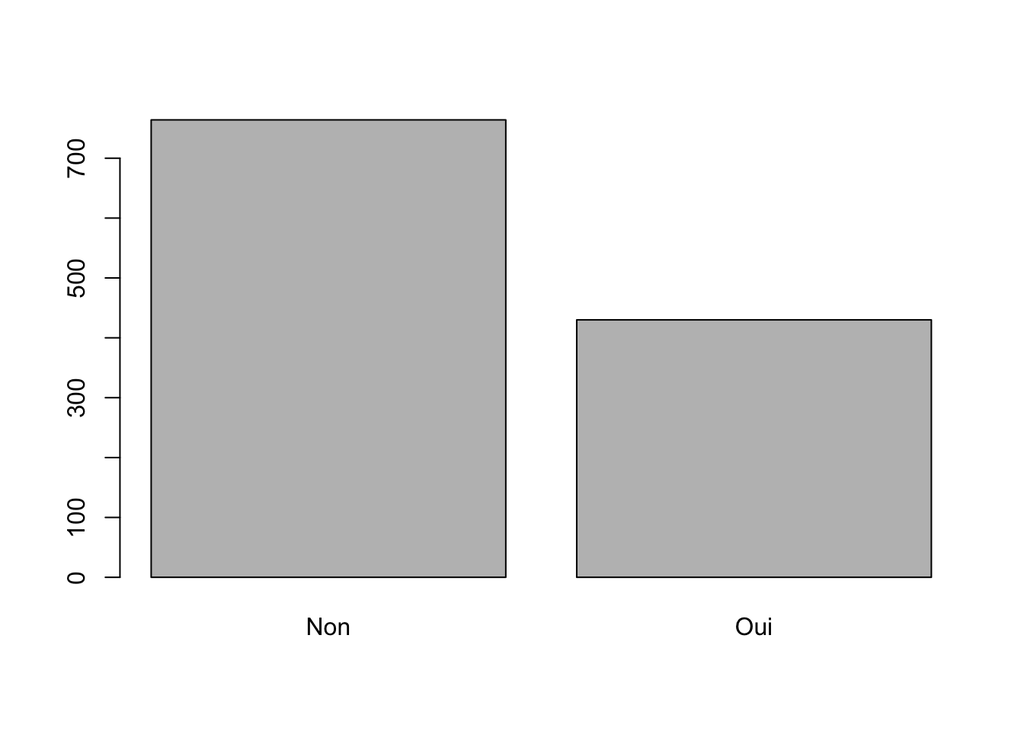

```r
barplot(mytab1)
```

Améliorer le graphique avec des titres et des couleurs

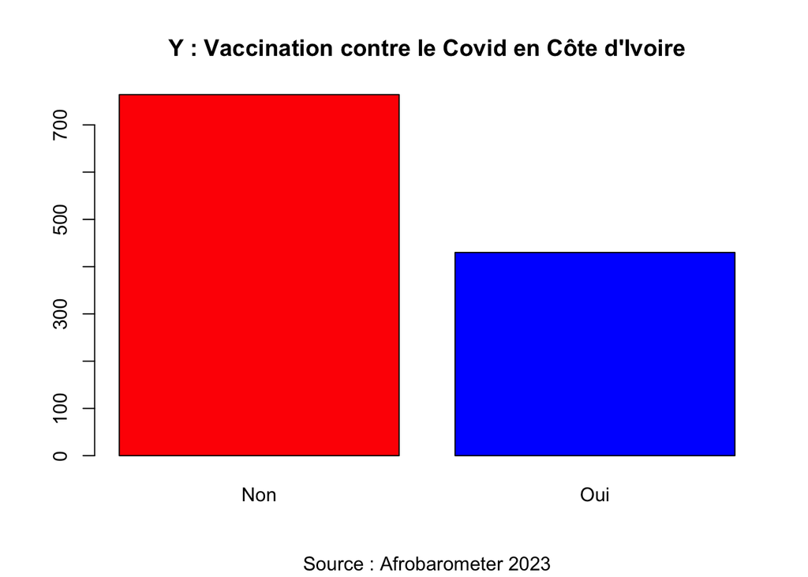

```r
barplot(mytab1,
        main = "Y : Vaccination contre le Covid en Côte d'Ivoire",
        sub = "Source : Afrobarometer 2023",
        col = c("red","blue"))
```

### Camembert

On peut également faire un camenbert si on préfère avec pie()

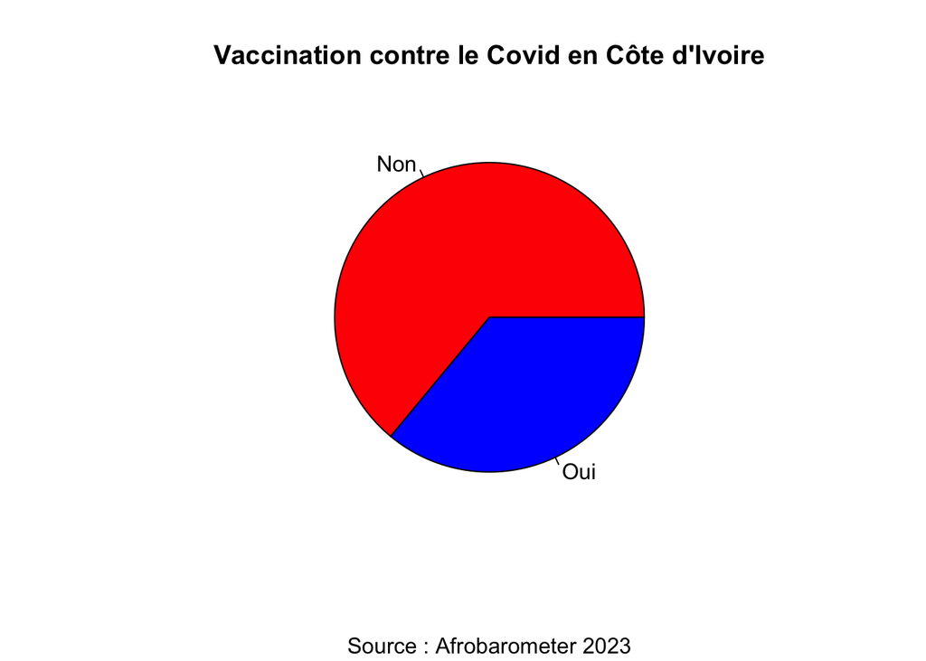

```r
pie(mytab1,
        main = "Vaccination contre le Covid en Côte d'Ivoire",
        sub = "Source : Afrobarometer 2023",
        col = c("red","blue"))
```

## 2.2 Analyse de la variable explicative (indépendante) X

On suppose que la variable explicative (indépendante) est age3 (âge en trois classes)

### Fréquence simple

Calculer les fréquences de chaque classe

```r
mytab2 <-table(sel$age3)
mytab2
```

```
- de 30 ans   30-50 ans + de 50 ans
        479         557         158
```

### Pourcentage

On peut ensuite facilement calculer les valeurs en pourcentage en utlisant la fonction `prop.table()` de R-base

```r
100*prop.table(mytab2)
```

```
- de 30 ans   30-50 ans + de 50 ans
   40.11725    46.64992    13.23283
```

### Diagramme en bâton

Visualiser la table avec barplot :

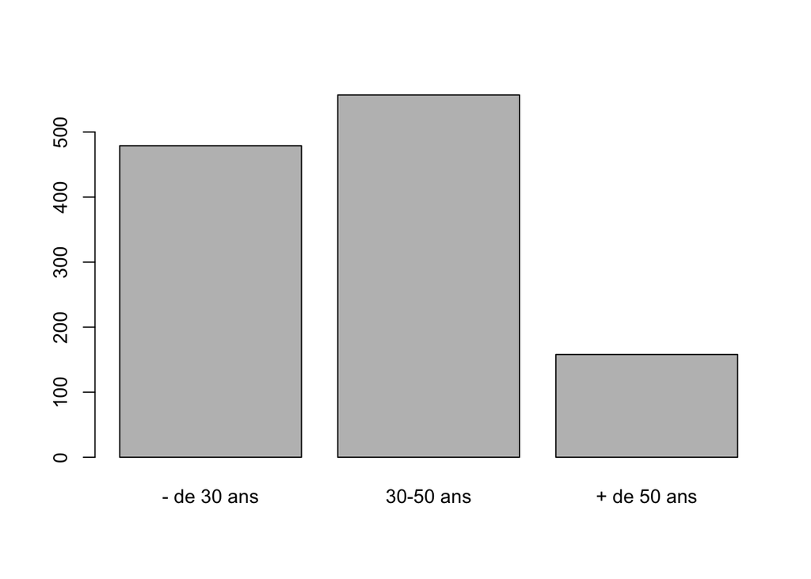

```r
barplot(mytab2)
```

Améliorer le graphique en ajoutant des titres et des couleurs adaptées :

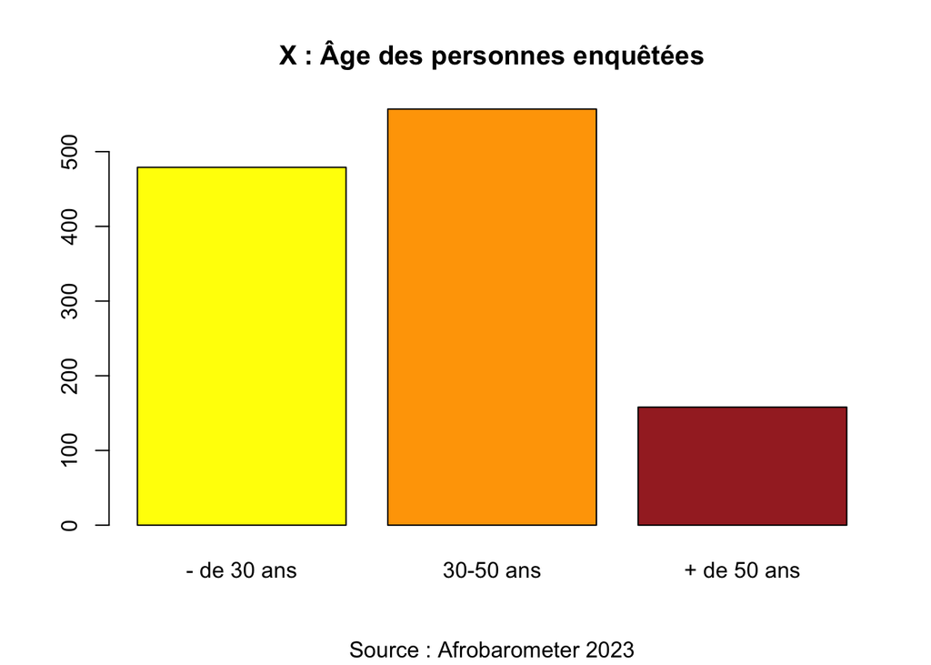

```r
barplot(mytab2,
        main = " X : Âge des personnes enquêtées ",
        sub = "Source : Afrobarometer 2023",
        col = c("yellow","orange","brown"))
```

# 3. ANALYSE BIVARIEE

## Objectif

On veut tester l’existence d’une relation entre les deux variables précédentes. Vous devez formuler deux hypothèses alternatives :

H0 : Il n’y a pas de relation entre X et Y H1 : Il y a une relation entre X et Y

## 3.1 Création du tableau de contingence

### Tableau brut

Créer un tableau de contingence en indiquant en premier la variable indépendante (X) et en second la variable à expliquer (Y)

```r
tabcont<-table(sel$age3,sel$vac)
tabcont
```

```
              Non Oui
  - de 30 ans 336 143
  30-50 ans   346 211
  + de 50 ans  82  76
```

### Ajout des marges

Ajouter à votre tableau les sommes des lignes et des colonnes :

```r
tabtot <- addmargins(tabcont)
tabtot
```

```
               Non  Oui  Sum
  - de 30 ans  336  143  479
  30-50 ans    346  211  557
  + de 50 ans   82   76  158
  Sum          764  430 1194
```

### Pourcentage en ligne

Calculez les pourcentages en lignes pour voir si la fréquence des modalités de Y varie en fonction de celles de X

```r
tabpct <- 100*prop.table(tabcont,1) # Calcule le pourcentage en ligne (1)
round(tabpct,1)                     # Arrondi à un chiffre après la virgule
```

```
               Non  Oui
  - de 30 ans 70.1 29.9
  30-50 ans   62.1 37.9
  + de 50 ans 51.9 48.1
```

- **Commentaire** : Il semble en effet y avoir une relation entre les deux variables. Le taux de personnes vaccinés est plus faible chez les jeunes (30%) que chez les adultes (38%) ou les vieux (48%).

## 3.2 Visualisation de la relation

Construire un graphique en mosaïque avec mosaicplot()

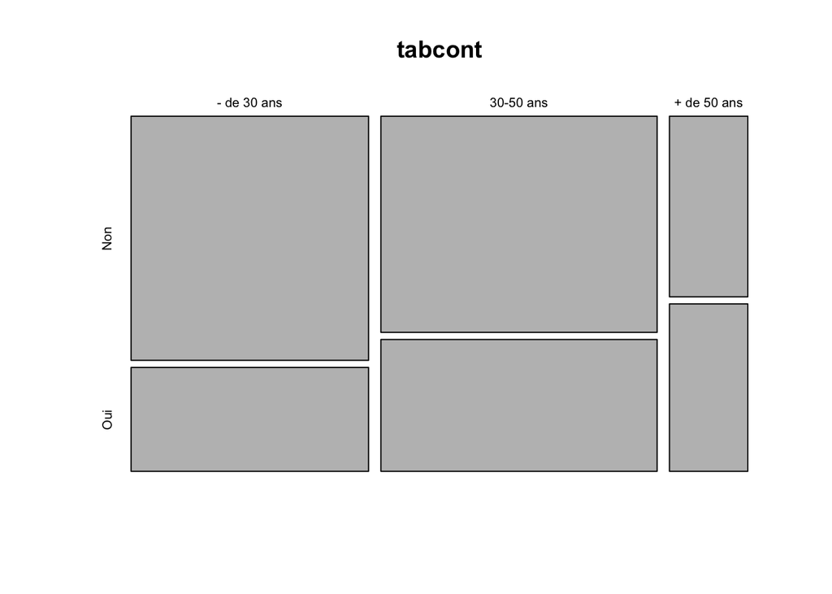

```r
mosaicplot(tabcont)
```

Améliorer le graphique avec des titres et des couleurs :

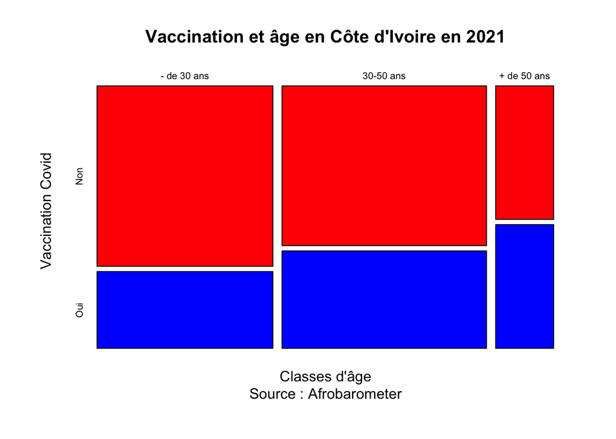

```r
mosaicplot(tabcont,
           main= "Vaccination et âge en Côte d'Ivoire en 2021",
           sub = "Source : Afrobarometer",
           xlab = "Classes d'âge",
           ylab = "Vaccination Covid",
           col = c("red","blue"))
```

## 3.3 Test du chi-2

On va tester si les différences de pourcentage sont significatives ou sont l’effet du hasard.

### Hypothèse nulle

Rappelez l’hypothèse H0 :

H0 : il n’y a pas de relation entre X et Y. Les variations en Y en fonction de X sont l’effet du hasard.

### Test

Réalisez un test du chi-2 à l’aide de la fonction chisq.test() et commentez les résultats du test.

```r
chisq.test(tabcont)
```

```
    Pearson's Chi-squared test

data:  tabcont
X-squared = 18.748, df = 2, p-value = 8.488e-05
```

- **Commentaire** : Notre tableau comportait 3 lignes et 2 colonnes et avait donc **2 degrés de liberté**. Le chi-2 du tableau est de **18.74** ce qui donne une p-value de **0.000085**. Il y a donc moins d’une chance sur 1000 (p < 0.001) que les différences soient l’effet du hasard et que H0 soit vraie.

### Conclusion

Au vu des résultats on rejette H0 et on accepte H1. On conclue avec un risque d’erreur très faible (p < 0.001) qu’**il existe une relation entre l’âge et le fait d’être vacciné en Côte d’Ivoire en 2021**.

L’explication paraît à première vue assez simple. En effet la pandémie de Covid était particulèrement dangereuse pour les personnes âgées, ce qui a pu pousser à les vacciner en priorité. Mais d’autres interprétations ne sont pas à exclure. Par exemple une plus grande méfiance des jeunes ? une plus grande insouciance ? des revenus insuffisants pour payer le vaccin ? etc.

# 4. A VOUS DE JOUER…

Testez rapidement trois autres relations possibles

## 4.1 Vaccination et sexe

```r
# tableau de contingence
tabcont <- table(sel$sex,sel$vac)
tabcont
```

```
        Non Oui
  Femme 403 195
  Homme 361 235
```

```r
# Pourcentages
prop.table(tabcont,1)
```

```
              Non       Oui
  Femme 0.6739130 0.3260870
  Homme 0.6057047 0.3942953
```

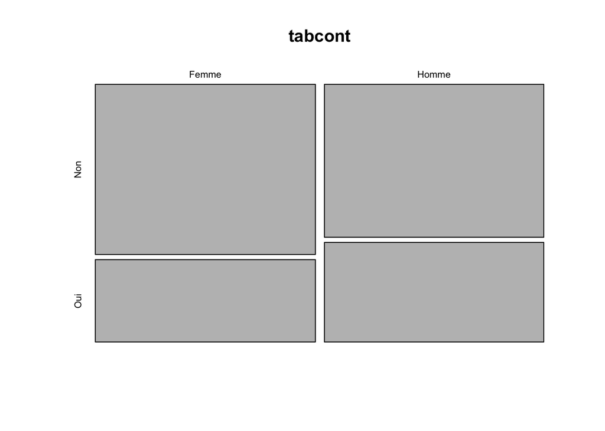

```r
# graphique
plot(tabcont)
```

```r
# test
chisq.test(tabcont)
```

```
    Pearson's Chi-squared test with Yates' continuity correction

data:  tabcont
X-squared = 5.7341, df = 1, p-value = 0.01664
```

- **Conclusion** : Les femmes sont dans l’ensemble moins vaccinées (32.5%) que les hommes (39.5%). On peut affirmer avec un risque d’erreur inférieur à 0.05 que cette relation est significative.

## 4.2 Vaccination et milieu urbain-rural

```r
# tableau de contingence
tabcont <- table(sel$mil,sel$vac)
tabcont
```

```
         Non Oui
  Rural  332 210
  Urbain 432 220
```

```r
# Pourcentages
prop.table(tabcont,1)
```

```
               Non       Oui
  Rural  0.6125461 0.3874539
  Urbain 0.6625767 0.3374233
```

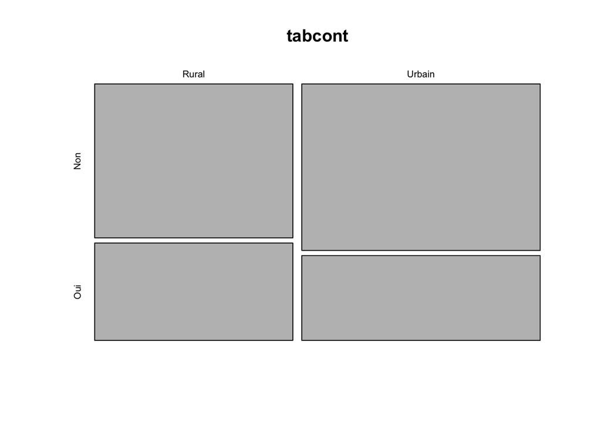

```r
# graphique
plot(tabcont)
```

```r
# test
chisq.test(tabcont)
```

```
    Pearson's Chi-squared test with Yates' continuity correction

data:  tabcont
X-squared = 3.0014, df = 1, p-value = 0.08319
```

- **Conclusion** : Le taux de vaccination est plus élevé dans les zones ruales (38.6%) que dans les zones urbaines (33.8%). Mais le text du chi-2 nous indique que la différence n’est pas tout à fait sigificative au seul habituel p < 0.05. Il faudrait prendre un risque d’erreur de 10% pour rejeter H0. Dans ce type de situation où la p-value est comprise entre 0.05 et 0.10 on ne dit pas qu’il n’y a pas de relation mais que l’échantillon d’enquête est de taille insuffisante pour conclure avec certitude à l’existence d’une relation.

## 4.4 Vaccination et instruction

```r
# tableau de contingence
tabcont <- table(sel$ins4, sel$vac)
tabcont
```

```
        Non Oui
  Inf.  130  71
  Prim. 195 125
  Sec.  318 178
  Sup.  121  56
```

```r
# Pourcentages
prop.table(tabcont,1)
```

```
              Non       Oui
  Inf.  0.6467662 0.3532338
  Prim. 0.6093750 0.3906250
  Sec.  0.6411290 0.3588710
  Sup.  0.6836158 0.3163842
```

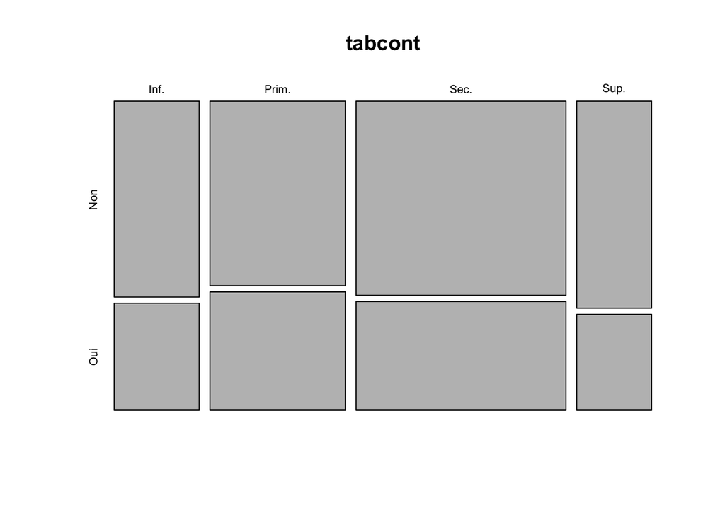

```r
# graphique
plot(tabcont)
```

```r
# test
chisq.test(tabcont)
```

```
    Pearson's Chi-squared test

data:  tabcont
X-squared = 2.8062, df = 3, p-value = 0.4225
```

- **Conclusion** : Le taux de vacination le plus élevé concerne les personnes ayant un niveau d’étude primaire (39%) et le plus faible les personnes ayant un niveau d’instruction supérieur (31.6%). Mais le test du chi-2 montre qu’il n’y a aucune relation entre le fait d’être vacciné et le niveau d’instruction (p= .42 > 0.05). C’est un résultat négatif mais intéressant car on aurait pu penser que le contraire serait vrai.